# Project 4, APS1070 Fall 2022

#### **Linear Regression - 14 points**

**Deadline: Dec 1st, 21:00**

**Academic Integrity**

This project is individual - it is to be completed on your own. If you have questions, please post your query in the APS1070 Piazza Q&A forums (the answer might be useful to others!).

Do not share your code with others, or post your work online. Do not submit code that you have not written yourself. Students suspected of plagiarism on a project, midterm or exam will be referred to the department for formal discipline for breaches of the Student Code of Conduct.

Please fill out the following:

- Your **name**: Kecheng Xiao
- Your **student number**: 1008709140

### How to submit **(HTML [This notebook] + IPYNB + GitHub [Part 7])**

1. Download your notebook: `File -> Download .ipynb`
2. Click on the Files icon on the far left menu of Colab
3. Select & upload your `.ipynb` file you just downloaded, and then obtain its path (right click) (you might need to hit the Refresh button before your file shows up)
1. execute the following in a Colab cell:

   ```
   %%shell
   jupyter nbconvert --to html /PATH/TO/YOUR/NOTEBOOKFILE.ipynb
   ```

2. An HTML version of your notebook will appear in the files, so you can download it.
3. Submit **both** `HTML` and `IPYNB` files for this notebook on Quercus for grading.
4. Make sure you completed the last part on **GitHub** and added your link to the last cell here. The teaching team will view and grade your part 7 on GitHub.

Ref: https://stackoverflow.com/a/64487858

## Part 1 - Getting Started [1 marks]

Ailerons are small hinged sections on the outboard portion of a wing used to control the roll of an airplane. In this project, we are going to design a controller to manage the ailerons of an aircraft based on supervised learning.

[figure not shown]

The following dataset contains 13750 instances, where each instance is a set of 40 features describing the airplane's status. Our goal is to use these features to predict the `Goal` column, which is a command that our controller should issue. We will make our predictions by implementing linear regression.

```python
import pandas as pd
import numpy as np
import time
import warnings
warnings.filterwarnings('ignore')

from matplotlib import pyplot as plt
from sklearn.model_selection import train_test_split
from sklearn.preprocessing import StandardScaler
from sklearn.metrics import mean_squared_error
```

```python
df = pd.read_csv("https://raw.githubusercontent.com/aps1070-2019/datasets/master/F16L.csv" , skipinitialspace=True)
```

Here are the steps to complete this portion:

1. Print the dataframe.
2. Prepare your dataset as follows: **[0.5]**
   - Using `train_test_split` from Sklearn, split the dataset into training, validation, and test sets ($70\%$ training, $15\%$ validation, and $15\%$ test). When splitting, set `random_state=1`.
   - Standardize the data using `StandardScaler` from sklearn.
   - Insert the first column of all $1$s in the training, validation, and test set.
3. Explain the difference between epoch and iteration in the Gradient descent algorithm (SGD/mini-batch)? **[0.5]**

```python
# 1 Print dataframe
df
```

|  | inputs ClimbRate | Sgz | P | Q | CurPitch | CurRoll | AbsRoll | DiffClb | DiffRollRate | DiffDiffClb | ... | DiffSeTime8 | DiffSeTime9 | DiffSeTime10 | DiffSeTime11 | DiffSeTime12 | DiffSeTime13 | DiffSeTime14 | Alpha | Se | Goal |
| --- | --- | --- | --- | --- | --- | --- | --- | --- | --- | --- | --- | --- | --- | --- | --- | --- | --- | --- | --- | --- | --- |
| 0 | -17 | -6 | -0.03 | 0.14 | 0.59 | -0.5 | -11 | -9 | 0.015 | -0.2 | ... | 0.0 | 0.000 | 0.0 | 0.000 | 0.0 | 0.000 | 0.0 | 0.6 | 0.021 | -0.0008 |
| 1 | -791 | 15 | -0.28 | -0.34 | 1.11 | 0.9 | -10 | 27 | -0.002 | 4.7 | ... | 0.0 | 0.000 | 0.0 | 0.000 | 0.0 | 0.000 | 0.0 | 0.4 | 0.013 | -0.0009 |
| 2 | -46 | 48 | -0.42 | 0.07 | 0.57 | 0.6 | -5 | -8 | -0.008 | 0.0 | ... | 0.0 | 0.000 | 0.0 | 0.000 | 0.0 | 0.000 | 0.0 | 0.5 | 0.019 | -0.0005 |
| 3 | 496 | -5 | -0.21 | -0.04 | 0.03 | -0.5 | -7 | 6 | -0.002 | -0.1 | ... | 0.0 | 0.000 | 0.0 | 0.001 | 0.0 | 0.001 | 0.0 | 0.5 | 0.017 | -0.0005 |
| 4 | -124 | 16 | -0.02 | 0.05 | 0.61 | -0.2 | -9 | -3 | 0.000 | 0.0 | ... | 0.0 | 0.000 | 0.0 | 0.000 | 0.0 | 0.000 | 0.0 | 0.5 | 0.018 | -0.0006 |
| ... | ... | ... | ... | ... | ... | ... | ... | ... | ... | ... | ... | ... | ... | ... | ... | ... | ... | ... | ... | ... | ... |
| 13745 | -53 | -13 | -0.07 | 0.02 | 0.58 | -2.3 | -15 | 12 | 0.022 | -0.8 | ... | 0.0 | 0.000 | 0.0 | 0.000 | 0.0 | -0.001 | 0.0 | 0.5 | 0.019 | -0.0007 |
| 13746 | 1 | 4 | -0.11 | -0.07 | 0.47 | 0.8 | -5 | 8 | -0.003 | -0.2 | ... | 0.0 | 0.000 | 0.0 | 0.000 | 0.0 | 0.000 | 0.0 | 0.5 | 0.016 | -0.0004 |
| 13747 | 425 | -14 | 0.40 | 0.07 | 0.41 | -2.1 | -16 | 12 | 0.031 | -0.7 | ... | 0.0 | 0.001 | 0.0 | 0.000 | 0.0 | 0.001 | 0.0 | 0.9 | 0.032 | -0.0015 |
| 13748 | 102 | -10 | -0.19 | 0.08 | 1.30 | 0.5 | -10 | -3 | -0.003 | -0.2 | ... | 0.0 | 0.000 | 0.0 | 0.000 | 0.0 | 0.000 | 0.0 | 1.4 | 0.051 | -0.0015 |
| 13749 | -165 | 52 | 0.08 | 0.42 | 1.07 | -1.6 | -22 | -15 | 0.007 | 0.0 | ... | 0.0 | 0.000 | 0.0 | 0.000 | 0.0 | 0.000 | 0.0 | 0.9 | 0.034 | -0.0018 |

13750 rows × 41 columns

```python
X = df.drop(columns=['Goal']).values
y = df['Goal'].values
```

```python
# 2 Prepare dataset
# split
X_train, X_test, y_train, y_test = train_test_split(X, y, test_size=15/100,  random_state=1)
X_train, X_val, y_train, y_val = train_test_split(X_train, y_train, test_size=15/85,  random_state=1)

# standardize
scaler = StandardScaler()
X_train = scaler.fit_transform(X_train)
X_val = scaler.transform(X_val)
X_test = scaler.transform(X_test)

# insert 1s
# add bias column
X_train = np.c_[np.ones(X_train.shape[0]), X_train]
X_val = np.c_[np.ones(X_val.shape[0]), X_val]
X_test = np.c_[np.ones(X_test.shape[0]), X_test]
```

#### Q: Epoch vs Iteration

The difference is on the unit:

- Epoch: one epoch is when an entire dataset is passed
- Iteration: iterations are the number of batches needed to complete one epoch

## Part 2 - Linear Regression Using Direct Solution [1 marks]

Implement the direct solution of the linear regression problem on the training set. **[0.5]**

**Note:** You should use **`scipy.linalg.inv`** to perform the matrix inversion, as `numpy.linalg.inv` may cause numerical issues.

Report the root-mean-square error (RMSE) for both the training and validation sets. **[0.5]**

You may use `mean_squared_error` from Sklearn for computing the RMSE.

```python
# direct solution
# analytical solution
W = np.dot(np.linalg.inv(np.dot(X_train.T, X_train)), np.dot(X_train.T, y_train))

# prediction
y_train_pred = np.dot(X_train, W)
y_val_pred = np.dot(X_val, W)

def rmse(y_pred_, y_):
    return np.sqrt(mean_squared_error(y_, y_pred_))

print('Training RMSE:', rmse(y_train_pred, y_train))
print('Validation RMSE:', rmse(y_val_pred, y_val))
```

```
Training RMSE: 0.0001762502876605019
Validation RMSE: 0.000171161039364294
```

## Part 3 - Full Batch Gradient Descent [2 marks]

We will now implement a "full batch" gradient descent algorithm and record the training time for our model. Recall that the full batch gradient descent is, $$w_t = w_{t-1} - \alpha~g_t$$ where $\alpha$ is the learning rate and $g_t$ is your gradient, computed on the entire data.

Here are the steps for this part:

- Implement gradient descent for linear regression using a fixed learning rate of $\alpha= 0.01$, and iterate until your model's **validation** RMSE converges.

  We consider the gradient descent as having converged when RMSE on the validation set using gradient descent satisfies:

  $$ RMSE_\text{GD} \leq 1.001 \times RMSE_\text{Direct Solution}$$

  where $RMSE_\text{Direct Solution}$ is the RMSE on the validation set using the direct solution that you have calculated in the previous part.

  We refer to the quantity $RMSE_\text{Direct Solution}\times 1.001$ as the convergence threshold (CT).
- Record the training time (from the first iteration until convergence) using the `time.time()` function. Be sure to compute the gradients yourself! Take a look at the code provided in the tutorial. **[0.5]**
- Plot the training RMSE and the validation RMSE vs. epoch on the same figure. **[0.5]**
- Comment on overfitting/underfitting by observing the training and validation RMSE **[1]**

**Hint**: Initialize your weights with small random numbers (<$0.001$)

```python
## GD Script -- Sample code in tutorial! ##
def gradient_descent_full_batch(X_train_, y_train_, X_val_, y_val_,
                                learning_rate=0.01, rmse_direct= rmse(y_val_pred, y_val)):
    start_time = time.time() ## Records current time
    W_ = np.random.random(X_train_.shape[1])/1000 ### initial random weights
    lr_ = learning_rate
    rmse_val_array_ = []
    rmse_train_array_ = []

    # initial validate value
    y_val_pred_ = np.dot(X_val_, W_.T)
    rmse_val_array_.append(rmse(y_val_pred_, y_val_))

    # for the rest epoch
    while rmse_val_array_[-1] > 1.001 * rmse_direct:
        # validation update
        y_val_pred_ = np.dot(X_val_, W_.T)
        rmse_val_array_.append(rmse(y_val_pred_, y_val_))
        # training update
        y_train_pred_ = np.dot(X_train_, W_.T)
        rmse_train_array_.append(rmse(y_train_pred_, y_train_))
        # update gradient
        gradient_ = (1/len(y_train_pred_) * np.dot(X_train_.T, (y_train_pred_ - y_train_)))
        W_ = W_ - lr_ * gradient_ ### weight update

    # remove the initial
    rmse_val_array_.pop(0)
    # plot
    plt.figure(figsize=(16, 9))
    plt.plot(range(100), rmse_train_array_[:100], label='Training')
    plt.plot(range(100), rmse_val_array_[:100], label='Validation')
    plt.xlabel("Epoch", fontsize=14)
    plt.ylabel("RMSE", fontsize=14)
    plt.title('Full Batch Gradient Descent Iteration', fontsize=16)
    plt.legend(fontsize=14)
    print("--- Total Training Time: %s (s) ---" % (time.time() - start_time))
```

```
--- Total Training Time: 6.659127950668335 (s) ---
```

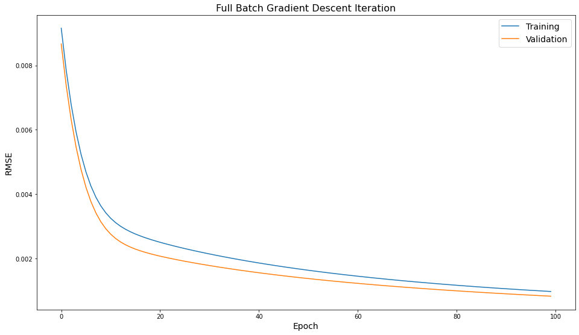

```python
gradient_descent_full_batch(X_train, y_train, X_val, y_val)
```

#### Comment

The training and validation RMSE curves drop with similar rates during the training phase. So, there is no obvious sign of overfitting, since the validation result is good; also no underfitting due to the consistent decrease of RMSE.

## Part 4 - Mini-batch and Stochastic Gradient Descent [4 marks]

Write a function that performs mini-batch gradient descent until the convergence threshold (CT) is reached. **[1]**

The inputs of that function are:

- Input data (training/validation), Batch size, Learning Rate, Convergence Threshold (CT)

Your function will return the following arrays:

- The final weights after training.
- The training RMSE at each epoch.
- The validation RMSE at each epoch.
- An array that has the elapsed time from the start of the training process to the end of each epoch (e.g., if each epoch takes exactly 2 seconds, the array would look like: [2 4 6 8 ...]).

Notes:

- For certain batch sizes, GD might not converge to a solution. For that reason, you need to check the RMSE of the validation/training set at each epoch, and if it's getting larger and larger, you should stop the training for that case (the design is up to you!).
- CT will help you to know when your model is converged.
- **Important: after each epoch, you need to shuffle the entire training set.** This ensures that new mini-batches are selected for every epoch. Hint: use `np.random.permutation`.

Let's now use the function to investigate the effect of batch size on convergence. When the batch size is 1, we call that stochastic gradient descent. When the batch size equals the # of training data, it is full-batch (i.e., all data points are used at every iteration). Anywhere in between is mini-batch (we use some data).

- Sweep different values for the mini-batch size (at least 5 values that **converge**), each time using a learning rate of $\alpha= 0.01$. **Hint: Try batch sizes that are powers of two (e.g., 2,4,8,16,32,64,128...).** These batch sizes fit better on the hardware and may achieve higher performance. **[0.5]**

Provide the following $3$ plots:

1. Plot training and validation RMSE vs. **epoch** for all the **converging** batch sizes (some batch sizes might not converge) in a figure. The X-axis is Epoch # and the Y-axis is RMSE. **[0.5]**
2. Plot training and validation RMSE vs. **time** for all the **converging** batch sizes in a figure. The X-axis is Time, and the Y-axis is RMSE. **[0.5]**
3. Plot Total training time (y-axis) vs. Batch size (x-axis). **[0.5]**

Describe your findings, including the main takeaways from each of your plots. **[1]**

```python
def gradient_descent_mini_batch(X_train_, y_train_, X_val_, y_val_,
                                batch_size_power2, learning_rate=0.01, threshold=rmse(y_val_pred, y_val)):

    W_ = np.random.random(X_train_.shape[1])/1000 ### initial random weights
    lr_ = learning_rate
    rmse_val_array_ = []
    rmse_train_array_ = []
    process_time_array_ = []
    batch_size = 2**batch_size_power2
    flag_converge = True
    c_diverge = 8

    # initial validate value
    y_val_pred_ = np.dot(X_val_, W_.T)
    rmse_val_array_.append(rmse(y_val_pred_, y_val_))

    # records current time
    start_time = time.time()

    # for the rest epoch
    while rmse_val_array_[-1] > 1.001 * threshold and flag_converge:
        # validation update
        y_val_pred_ = np.dot(X_val_, W_.T)
        rmse_val = rmse(y_val_pred_, y_val_)
        rmse_val_array_.append(rmse_val)

        # check diverge
        if len(rmse_val_array_) > c_diverge:
            rmse_check_ = rmse_val_array_[-c_diverge:]
            if all([rmse_check_[-r] > rmse_check_[-(r+1)]
                    for r in range(1,len(rmse_check_))]):
                print('Diverge at Batch Size = %d'%(2**batch_size_power2))
                flag_converge = False

        # training update
        y_train_pred_ = np.dot(X_train_, W_.T)
        rmse_train = rmse(y_train_pred_, y_train_)
        rmse_train_array_.append(rmse_train)

        # batch gradient update
        for b in range(0, X_train_.shape[0], batch_size):
            X_batch = X_train_[b:b + batch_size]
            y_batch = y_train_[b:b + batch_size]
            y_pred_batch = np.dot(X_batch, W_.T)
            gradient_ = (1/len(y_pred_batch) * np.dot(X_batch.T, (y_pred_batch - y_batch)))
            W_ = W_ - lr_ * gradient_

        # add time
        process_time_array_.append(time.time() - start_time)

        # shuffle X
        rand = list(np.random.permutation(X_train_.shape[0]))
        X_train_ = X_train_[rand]
        y_train_ = y_train_[rand]

    # remove the initial
    rmse_val_array_.pop(0)

    return W_, rmse_train_array_, rmse_val_array_, process_time_array_, flag_converge
```

```
Diverge at Batch Size = 2
Diverge at Batch Size = 4
Diverge at Batch Size = 8
Diverge at Batch Size = 16
Diverge at Batch Size = 32
```

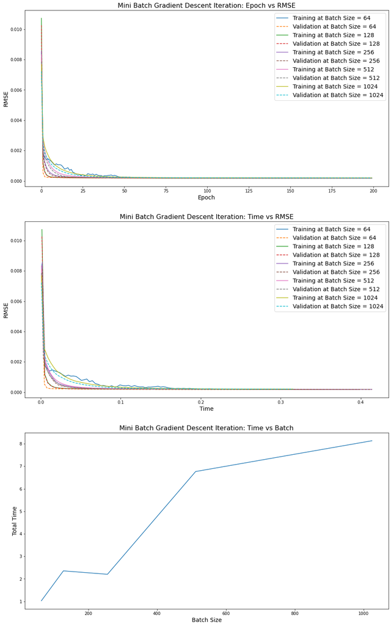

```
Fastest Converge Batch Size: 64
```

```python
plt.figure(figsize=(16,27))
process_time_array = []
converge_batch = []
converge_time = []
np.random.seed(21)

for i in range(1, 11):
    W, rmse_train_array, rmse_val_array, process_time_array, flag =\
        gradient_descent_mini_batch(X_train, y_train, X_val, y_val, i)
    if flag:
        # plot rmse vs epoch
        plt.subplot(3,1,1)
        plt.plot(rmse_train_array[:200], label='Training at Batch Size = %d'%(2**i))
        plt.plot(rmse_val_array[:200], ls='--', label='Validation at Batch Size = %d'%(2**i))
        plt.xlabel("Epoch", fontsize=14)
        plt.ylabel("RMSE", fontsize=14)
        plt.title('Mini Batch Gradient Descent Iteration: Epoch vs RMSE', fontsize=16)
        plt.legend(fontsize=14)

        # plot rmse vs time
        plt.subplot(3,1,2)
        plt.plot(process_time_array[:100], rmse_train_array[:100], label='Training at Batch Size = %d'%(2**i))
        plt.plot(process_time_array[:100], rmse_val_array[:100], ls='--', label='Validation at Batch Size = %d'%(2**i))
        plt.xlabel("Time", fontsize=14)
        plt.ylabel("RMSE", fontsize=14)
        plt.title('Mini Batch Gradient Descent Iteration: Time vs RMSE', fontsize=16)
        plt.legend(fontsize=14)

        # save last time
        converge_batch.append(2**i)
        converge_time.append(process_time_array[-1])

plt.subplot(3,1,3)
plt.plot(converge_batch, converge_time)
plt.xlabel("Batch Size", fontsize=14)
plt.ylabel("Total Time", fontsize=14)
plt.title('Mini Batch Gradient Descent Iteration: Time vs Batch', fontsize=16)
plt.show()
# find fastest for Part 5
fastest_batch_size = converge_batch[converge_time.index(min(converge_time))]
print('Fastest Converge Batch Size: %d'%fastest_batch_size)
```

#### Comment

The Epoch vs RMSE and Time vs RMSE have similar results, the batch size of 64 has some ups and downs with the training RMSE value, but still be able to converge at the end.

After batch size = 64, all other batch sizes converge smoothly, and no many difference with training and validation curves. With increase of the batch size, the curves become more rounded and the RMSE drop slower.

From the Time vs Batch Size plot, we can conclude: in general, larger the batch size, longer the training time, but there is a drop at batch size = 256. The fastest converge time is obtained by the one with the smallest converged batch size, which is 64.

## Part 5 - Gradient Descent Learning Rate [2 marks]

Use the function that you designed in Part 4 to investigate the effect of learning rate on convergence.

1. Pick 3 batch-size that are not converging with a learning rate of $\alpha= 0.01$ (last part) and try to find a learning rate that results in convergence for each batch-size. Report your findings in a table. Mention batch size, learning rate, and training and validation RMSE. **[0.5]**
2. Select the best batch-size based on Part 4's fastest convergence time and sweep the learning rate (at least 10 values, all should converge) while applying Mini-batch GD.
   - Plot the training and validation RMSE vs. **epoch** (x-axis) for all the learning rates that you tried in a figure. **[0.5]**
   - Plot the training and validation RMSE vs. **time** (x-axis) for all the learning rates that you tried in a figure. **[0.5]**
   - Describe your findings, including the main takeaways from each of your plots. **[0.5]**

```python
# part 1
np.random.seed(21)
for lr in np.arange(0.0008, 0.0000, -0.0002):
    # show learning rate
    print('-----Learning Rate = %.4f-----'%lr)
    for i in range(2,5):
        W, rmse_train_array, rmse_val_array, process_time_array, flag =\
            gradient_descent_mini_batch(X_train, y_train, X_val, y_val, i, learning_rate=lr)
        if flag:
            # show converge results
            print('Time: %2.2f | Train RMSE: %.7f | Validate RMSE: %.7f | Batch Size = %d'%(process_time_array[-1], rmse_train_array[-1], rmse_val_array[-1], 2**i))
```

```
-----Learning Rate = 0.0008-----
Diverge at Batch Size = 4
Time: 1.81 | Train RMSE: 0.0001766 | Validate RMSE: 0.0001713 | Batch Size = 8
Time: 4.23 | Train RMSE: 0.0001767 | Validate RMSE: 0.0001713 | Batch Size = 16
-----Learning Rate = 0.0006-----
Time: 9.04 | Train RMSE: 0.0001762 | Validate RMSE: 0.0001713 | Batch Size = 4
Time: 6.14 | Train RMSE: 0.0001762 | Validate RMSE: 0.0001713 | Batch Size = 8
Time: 5.38 | Train RMSE: 0.0001765 | Validate RMSE: 0.0001713 | Batch Size = 16
-----Learning Rate = 0.0004-----
Time: 11.42 | Train RMSE: 0.0001762 | Validate RMSE: 0.0001713 | Batch Size = 4
Time: 8.21 | Train RMSE: 0.0001763 | Validate RMSE: 0.0001713 | Batch Size = 8
Time: 13.94 | Train RMSE: 0.0001764 | Validate RMSE: 0.0001713 | Batch Size = 16
-----Learning Rate = 0.0002-----
Time: 14.39 | Train RMSE: 0.0001766 | Validate RMSE: 0.0001713 | Batch Size = 4
Time: 19.88 | Train RMSE: 0.0001760 | Validate RMSE: 0.0001713 | Batch Size = 8
Time: 25.91 | Train RMSE: 0.0001765 | Validate RMSE: 0.0001713 | Batch Size = 16
```

```
Time: 0.30 | Train RMSE: 0.0001784 | Validate RMSE: 0.0001711 | LR = 0.0100
Time: 0.87 | Train RMSE: 0.0001765 | Validate RMSE: 0.0001712 | LR = 0.0095
Time: 0.96 | Train RMSE: 0.0001767 | Validate RMSE: 0.0001713 | LR = 0.0090
Time: 1.77 | Train RMSE: 0.0001762 | Validate RMSE: 0.0001713 | LR = 0.0085
Time: 0.78 | Train RMSE: 0.0001760 | Validate RMSE: 0.0001713 | LR = 0.0080
Time: 0.68 | Train RMSE: 0.0001768 | Validate RMSE: 0.0001713 | LR = 0.0075
Time: 1.03 | Train RMSE: 0.0001764 | Validate RMSE: 0.0001713 | LR = 0.0070
Time: 2.45 | Train RMSE: 0.0001759 | Validate RMSE: 0.0001713 | LR = 0.0065
Time: 1.18 | Train RMSE: 0.0001768 | Validate RMSE: 0.0001712 | LR = 0.0060
Time: 0.58 | Train RMSE: 0.0001767 | Validate RMSE: 0.0001713 | LR = 0.0055
Time: 2.51 | Train RMSE: 0.0001764 | Validate RMSE: 0.0001713 | LR = 0.0050
Fastest Converge Learning Rate: 0.0080
```

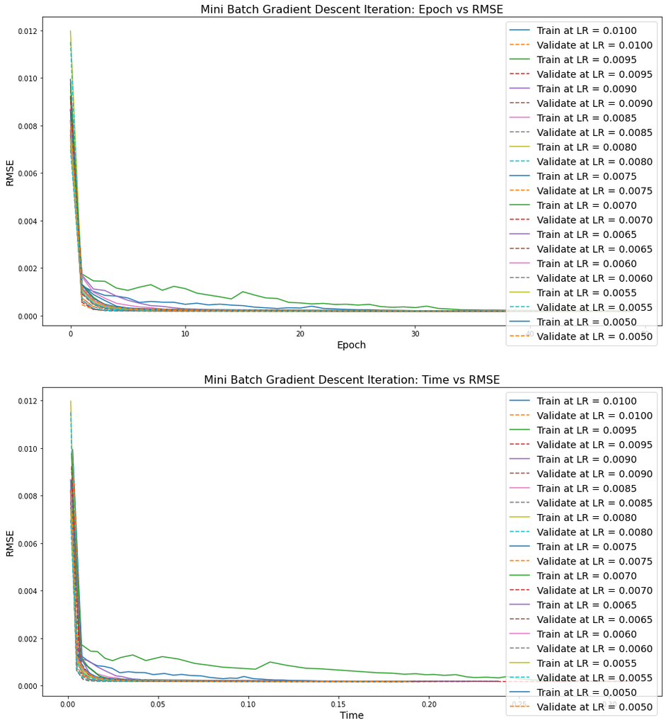

```python
# part 2
np.random.seed(21)
best_batch_time = []
plt.figure(figsize=(16,18))
f_size = int(np.log2(fastest_batch_size))
for lr in np.arange(0.01, 0.0045, -0.0005):
    W, rmse_train_array, rmse_val_array, process_time_array, flag = \
        gradient_descent_mini_batch(X_train, y_train, X_val, y_val, batch_size_power2=f_size, learning_rate=lr)
    if flag:
        # show converge results
        print('Time: %2.2f | Train RMSE: %.7f | Validate RMSE: %.7f | LR = %.4f'%(process_time_array[-1], rmse_train_array[-1], rmse_val_array[-1], lr))

        # plot rmse vs epoch
        plt.subplot(2,1,1)
        plt.plot(rmse_train_array[:50], label='Train at LR = %.4f' % lr)
        plt.plot(rmse_val_array[:50], ls='--', label='Validate at LR = %.4f' % lr)
        plt.xlabel("Epoch", fontsize=14)
        plt.ylabel("RMSE", fontsize=14)
        plt.title('Mini Batch Gradient Descent Iteration: Epoch vs RMSE', fontsize=16)
        plt.legend(fontsize=14)

        # plot rmse vs time
        plt.subplot(2,1,2)
        plt.plot(process_time_array[:50], rmse_train_array[:50], label='Train at LR = %.4f' % lr)
        plt.plot(process_time_array[:50], rmse_val_array[:50], ls='--', label='Validate at LR = %.4f' % lr)
        plt.xlabel("Time", fontsize=14)
        plt.ylabel("RMSE", fontsize=14)
        plt.title('Mini Batch Gradient Descent Iteration: Time vs RMSE', fontsize=16)
        plt.legend(fontsize=14)
    best_batch_time.append(process_time_array)

# find fastest for Part 6
lr_ls = list(np.arange(0.011, 0.000, -0.001))
fastest_lr = lr_ls[best_batch_time.index(min(best_batch_time))]
print('Fastest Converge Learning Rate: %.4f'%fastest_lr)
plt.show()
```

#### Comment

Adjust the learning to smaller values can help smaller batch size to converge, at learning rate = 0.0006, batch size 4, 8, 16 all converge successfully.

But decrease the batch size usually will cause a longer time to train, since the step is smaller. we can see, the training time is increase from less than 10s to near 25s.

The Epoch vs RMSE and Time vs RMSE still show the similar pattern, since we choose the batch size of 64. The fluctuation still exists, especially for relatively larger learning rates (0.01 and 0.0095).

## Part 6 - Finalizing a model [1 marks]

Based on your findings from the previous parts, pick a model (or combination of model settings) that you think would work best for our dataset and evaluate it on the test set.

Briefly describe your model selections/settings. **[0.5]**

Summarize the performance of your model for the task of managing ailerons of an aircraft. **[0.5]**

```
Time: 0.45 | Train RMSE: 0.0001814 | Test RMSE: 0.0001712 | LR = 0.008 | Batch Size = 64
```

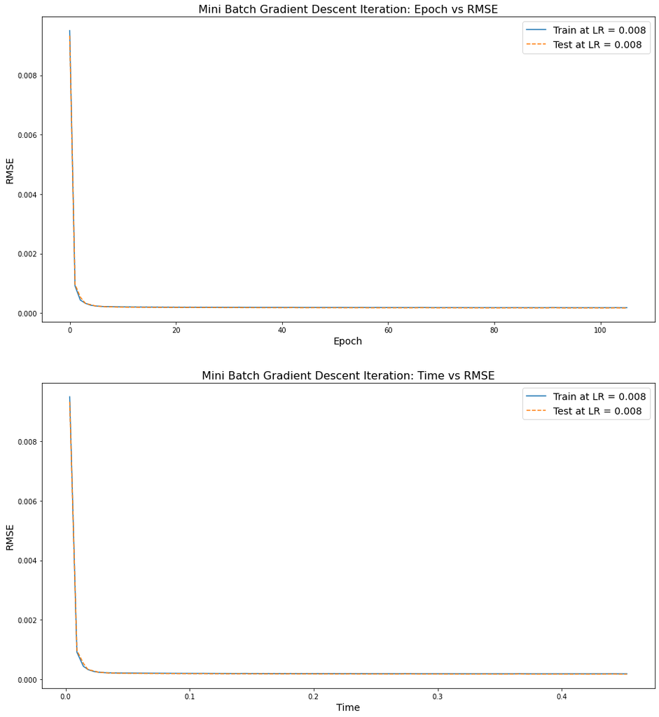

```python
plt.figure(figsize=(16,18))
lr = fastest_lr
W, rmse_train_array, rmse_val_array, process_time_array, flag =\
    gradient_descent_mini_batch(X_train, y_train, X_test, y_test, batch_size_power2=f_size, learning_rate=fastest_lr)
if flag:
    # show converge results
    print('Time: %2.2f | Train RMSE: %.7f | Test RMSE: %.7f | LR = %.3f | Batch Size = %d '%(process_time_array[-1], rmse_train_array[-1], rmse_val_array[-1], lr, 2**f_size))

    # plot rmse vs epoch
    plt.subplot(2,1,1)
    plt.plot(rmse_train_array, label='Train at LR = %.3f' % lr)
    plt.plot(rmse_val_array, ls='--', label='Test at LR = %.3f' % lr)
    plt.xlabel("Epoch", fontsize=14)
    plt.ylabel("RMSE", fontsize=14)
    plt.title('Mini Batch Gradient Descent Iteration: Epoch vs RMSE', fontsize=16)
    plt.legend(fontsize=14)

    # plot rmse vs time
    plt.subplot(2,1,2)
    plt.plot(process_time_array, rmse_train_array, label='Train at LR = %.3f' % lr)
    plt.plot(process_time_array, rmse_val_array, ls='--', label='Test at LR = %.3f' % lr)
    plt.xlabel("Time", fontsize=14)
    plt.ylabel("RMSE", fontsize=14)
    plt.title('Mini Batch Gradient Descent Iteration: Time vs RMSE', fontsize=16)
    plt.legend(fontsize=14)
plt.show()
```

```python
model_coef = pd.Series(W, index=['intercept']+list(df.columns[:-1]))
model_coef.sort_values(ascending=False)
```

```
CurPitch            5.547016e-04
inputs ClimbRate    4.330125e-04
AbsRoll             2.854654e-04
SeTime5             2.603669e-04
SeTime4             2.298133e-04
SeTime7             2.227199e-04
SeTime10            2.097228e-04
SeTime14            1.559426e-04
Q                   1.394755e-04
DiffClb             6.135101e-05
DiffDiffClb         5.291528e-05
Alpha               4.470691e-05
DiffRollRate        3.282697e-05
DiffSeTime3         1.541401e-05
SeTime12            1.537846e-05
DiffSeTime1         8.006127e-06
DiffSeTime9         6.731406e-06
Sgz                 4.936728e-06
DiffSeTime6         3.914609e-06
DiffSeTime13        3.380760e-06
DiffSeTime14        2.756464e-06
DiffSeTime12        1.995800e-06
DiffSeTime2         1.759840e-06
DiffSeTime10        1.673890e-06
DiffSeTime8        -3.199891e-07
DiffSeTime11       -3.506548e-06
DiffSeTime4        -3.979406e-06
DiffSeTime5        -9.147773e-06
SeTime11           -1.410596e-05
DiffSeTime7        -2.337769e-05
SeTime6            -6.657379e-05
SeTime2            -6.905904e-05
CurRoll            -8.443943e-05
SeTime9            -1.185247e-04
SeTime13           -1.249488e-04
P                  -1.305126e-04
SeTime3            -1.428268e-04
SeTime1            -1.844269e-04
SeTime8            -4.207982e-04
Se                 -5.275263e-04
intercept          -8.731486e-04
dtype: float64
```

#### Comment

Since the linear model with mini batch SGD can perform a good result(all converges), the optimization is on the train time, we find out large learning rate with small batch size may have issue to converge. Therefore, we firstly find the optimized batch size 64, with the fastest speed.

For the final performance on task of managing ailerons of an aircraft, the model found `CurPitch`, `inputs Climb Rate`, `AbsRoll`, `SeTime5` and some other SeTimes as the key features with testing RMSE= 0.0001712.

## Part 7 - Getting started with GitHub [3 marks]

This final part of the project assignment is to be completed independently of Parts 1 - 6. In this part you will be completing some additional coding tasks using a different dataset and submitting your results on GitHub. To access this part of the assignment and upload your answers, you will need to use GitHub. Please complete the following step-by-step instructions:

1. Create a GitHub account and install git for Windows or Mac:
   - https://git-scm.com/download/win
   - https://git-scm.com/download/mac
2. Open this link: https://classroom.github.com/a/ZC8Petsq to create your assignment repository in GitHub. You should get a link similar to:

   ```
   https://github.com/APS-1070-2021/f22-project4-git-*********
   ```

   This private repository to get this part questions and upload your answers. **Copy this link to the text box below to be graded for this part.**
1. Open `Git Bash`, the app you downloaded in step `0`, and set your Email and username by:

   ```
   git config --global user.email “<your-GitHub-email>”
   git config --global user.name “<your-GitHub-username>”
   ```

2. Create a folder for the course on your computer and `cd` to that. `cd` means `Change Directory`. For example, on a Windows machine, where I have a folder on "C:\aps1070":

   ```
   cd c:aps1070
   ```

3. Get your assignment by the link you got in step 1:

   ```
   git clone https://github.com/APS-1070-2021/f22-project4-git-*********
   ```

   If this is the first time you are using Git Bash, it will ask you to sign in on GitHub via your browser.
4. A new folder should be created in your directory similar to:

   ```
   C:\aps1070\f22-project4-git-********
   ```

   This folder has an `ipynb` notebook which you need to manually upload to colab and answer its questions.
5. After you finished working on this notebook, download the notebook from colab and move it to the directory in step 5.
6. Replace the old notebook with the new one that has your answers. Make sure your completed notebook has the same name as the original notebook you downloaded.
7. To submit your work, follow:

   ```
   cd <your assignment folder>
   git add F22_Project_4_git.ipynb
   git commit -m “Final Submission”
   git push
   ```

   If you had any problem with pushing your work on GitHub you can try one of following commands:

   ```
   git push --force
   or
   git push origin HEAD:main
   ```

8. Make sure your submission is ready for grading. Open the private repository link in your browser and make sure you can see your final submission with your latest changes there. **Only you and the teaching team can open that link.**

**Private Repository Link :** **https://github.com/APS-1070-2021/f22-project4-git-kxiao8**</font>